# Bone mineral density modelling: solution

1. Load data and packages

```r
library(mgcViz)
load(paste0(goodLocation, "/data/calcium.rda")) # change this

m1 <- gamV(bmd ~ group + age, data = calcium, aViz = list(nsim = 100))

summary(m1)
```

```
##
## Family: gaussian
## Link function: identity
##
## Formula:
## bmd ~ group + age
##
## Parametric coefficients:
##              Estimate Std. Error t value Pr(>|t|)
## (Intercept)  0.337882   0.051553   6.554  1.4e-10 ***
## groupP      -0.019539   0.006055  -3.227  0.00133 **
## age          0.049501   0.004282  11.560  < 2e-16 ***
## ---
## Signif. codes:  0 '***' 0.001 '**' 0.01 '*' 0.05 '.' 0.1 ' ' 1
##
##
## R-sq.(adj) =  0.221   Deviance explained = 22.4%
## -REML = -625.72  Scale est. = 0.004589  n = 501
```

Placebo has a negative effect, as one would expect.

2. Verify if the residual mean depends on the subject:

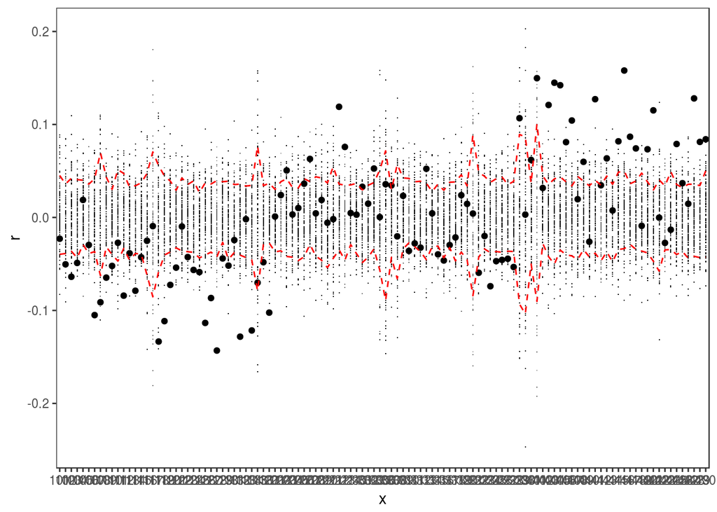

```r
check1D(m1, calcium$person) + l_gridCheck1D(mean)
```

We have some massive departures from 0, we need to include a random effect for subject:

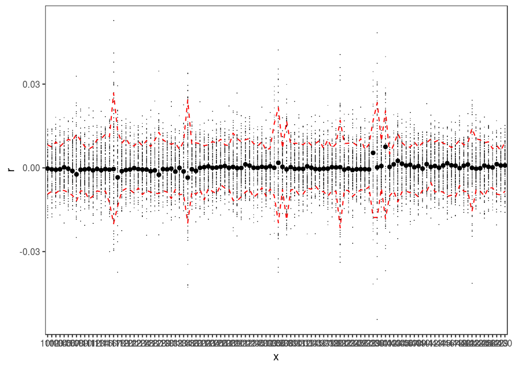

```r
m2 <- gamV(bmd ~ group + age + s(person, bs = "re"), data = calcium, aViz = list(nsim = 100))
check1D(m2, calcium$person) + l_gridCheck1D(mean)
```

```r
summary(m2)
```

```
##
## Family: gaussian
## Link function: identity
##
## Formula:
## bmd ~ group + age + s(person, bs = "re")
##
## Parametric coefficients:
##              Estimate Std. Error t value Pr(>|t|)
## (Intercept)  0.329263   0.015168  21.707   <2e-16 ***
## groupP      -0.019323   0.012785  -1.511    0.132
## age          0.050217   0.001017  49.394   <2e-16 ***
## ---
## Signif. codes:  0 '***' 0.001 '**' 0.01 '*' 0.05 '.' 0.1 ' ' 1
##
## Approximate significance of smooth terms:
##             edf Ref.df     F p-value
## s(person) 108.4    110 82.75  <2e-16 ***
## ---
## Signif. codes:  0 '***' 0.001 '**' 0.01 '*' 0.05 '.' 0.1 ' ' 1
##
## R-sq.(adj) =   0.96   Deviance explained = 96.9%
## -REML = -1121.3  Scale est. = 0.00023803  n = 501
```

Looks much better, obviously individual differences must be taken into account. However, notice that the effect of group (placebo vs calcium supplement) is much weaker now.

3. Maybe the effect of age is non-linear, we use a smooth effect here:

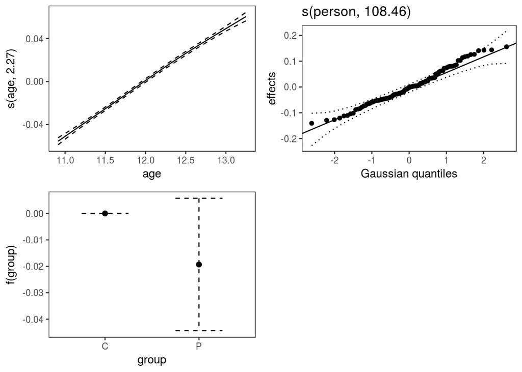

```r
m3 <- gamV(bmd ~ group + s(age) + s(person, bs = "re"), data = calcium)

print(plot(m3, allTerms = T), pages = 1)
```

```r
AIC(m2, m3)
```

```
##          df       AIC
## m2 112.4866 -2659.206
## m3 115.7722 -2658.101
```

Visually the effect of `age` seems fairly linear, but maybe it is slightly leveling off after ages 12. The AICs are comparable.

4. Verify whether the effect of `age` is different between groups:

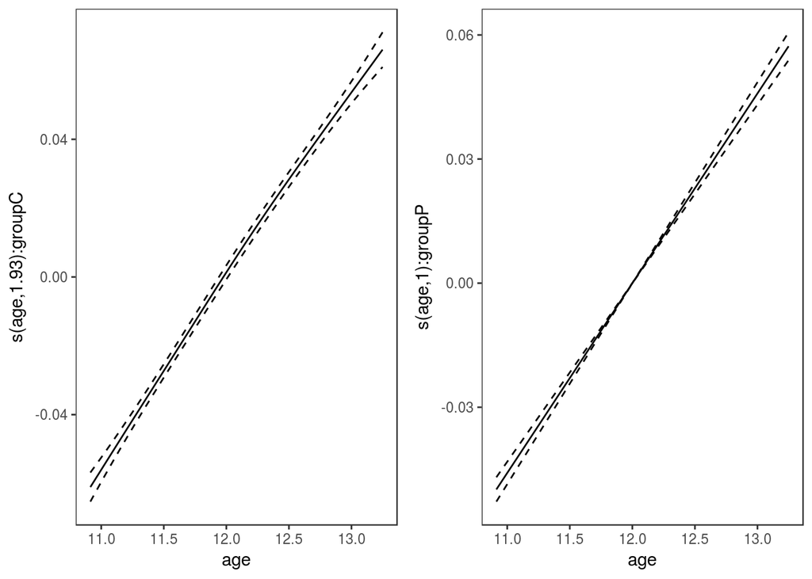

```r
m4 <- gamV(bmd ~ group + s(age, by = group) + s(person, bs = "re"), data = calcium)

print(plot(m4, select = 1:2), pages = 1)
```

Difficult to say by staring at the two effects above, better to plot the difference between the two smooths directly:

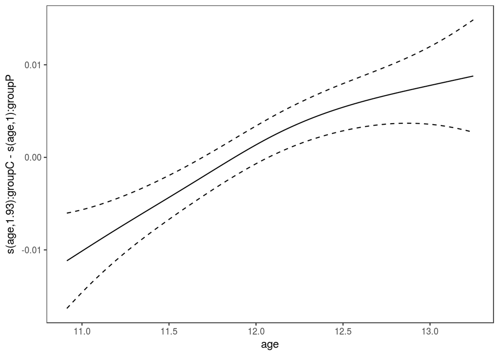

```r
plotDiff(sm(m4, 1), sm(m4, 2)) + l_fitLine() + l_ciLine()
```

There might actually be a difference: BMD increases faster in the group taking the supplement, and the effect might be levelling off after 12 years of age.